# IA-SVA based feature selection improves the performance of clustering algorithms [1]

Donghyung Lee

2018-04-18

The IA-SVA based feature selection can significantly improve the performance and utility of clustering algorithms (e.g., tSNE, hierarchical clustering). To illustrate how the IA-SVA method can be used to improve the performance of clustering algorithms, we used real-world single cell RNA sequencing (scRNA-Seq) data obtained from human pancreatic islet samples ([Lawlor et. al., 2016](http://genome.cshlp.org/content/early/2017/01/16/gr.212720.116)). This dataset is included in a R data package (“iasvaExamples”) containing data examples for IA-SVA (https://github.com/dleelab/iasvaExamples). To install the ‘iasvaExamples’ package, follow the instruction provided in the GitHub page.

## Load packages

```r
rm(list=ls())
library(irlba)
library(iasva)
library(iasvaExamples)
library(Rtsne)
library(pheatmap)
library(corrplot)
library(DescTools) #pcc i.e., Pearson's contingency coefficient
library(RColorBrewer)

color.vec <- brewer.pal(8, "Set1")
```

## Load the islet single cell RNA-Seq data (n=638 cells, and 26K genes)

```r
data("Lawlor_Islet_scRNAseq_Read_Counts")
data("Lawlor_Islet_scRNAseq_Annotations")
ls()
```

```
## [1] "color.vec"                         "Lawlor_Islet_scRNAseq_Annotations"
## [3] "Lawlor_Islet_scRNAseq_Read_Counts"
```

```r
counts <- Lawlor_Islet_scRNAseq_Read_Counts
anns <- Lawlor_Islet_scRNAseq_Annotations
dim(anns)
```

```
## [1] 638  26
```

```r
dim(counts)
```

```
## [1] 26542   638
```

```r
summary(anns)
```

```
##      run             cell.type             COL1A1          INS
##  Length:638         Length:638         Min.   :1.00   Min.   :1.000
##  Class :character   Class :character   1st Qu.:1.00   1st Qu.:1.000
##  Mode  :character   Mode  :character   Median :1.00   Median :1.000
##                                        Mean   :1.03   Mean   :1.414
##                                        3rd Qu.:1.00   3rd Qu.:2.000
##                                        Max.   :2.00   Max.   :2.000
##
##      PRSS1            SST             GCG            KRT19
##  Min.   :1.000   Min.   :1.000   Min.   :1.000   Min.   :1.000
##  1st Qu.:1.000   1st Qu.:1.000   1st Qu.:1.000   1st Qu.:1.000
##  Median :1.000   Median :1.000   Median :1.000   Median :1.000
##  Mean   :1.038   Mean   :1.039   Mean   :1.375   Mean   :1.044
##  3rd Qu.:1.000   3rd Qu.:1.000   3rd Qu.:2.000   3rd Qu.:1.000
##  Max.   :2.000   Max.   :2.000   Max.   :2.000   Max.   :2.000
##
##       PPY          num.genes             Cell_ID        UNOS_ID
##  Min.   :1.000   Min.   :3529   10th_C1_S59  :  1   ACCG268 :136
##  1st Qu.:1.000   1st Qu.:5270   10th_C10_S104:  1   ACJV399 :108
##  Median :1.000   Median :6009   10th_C11_S96 :  1   ACEL337 :103
##  Mean   :1.028   Mean   :5981   10th_C13_S61 :  1   ACIW009 : 93
##  3rd Qu.:1.000   3rd Qu.:6676   10th_C14_S53 :  1   ACCR015A: 57
##  Max.   :2.000   Max.   :8451   10th_C16_S105:  1   ACIB065 : 57
##                                 (Other)      :632   (Other) : 84
##       Age        Biomaterial_Provider    Gender              Phenotype
##  Min.   :22.00   IIDP      : 45       Female:303   Non-Diabetic   :380
##  1st Qu.:29.00   Prodo Labs:593       Male  :335   Type 2 Diabetic:258
##  Median :42.00
##  Mean   :39.63
##  3rd Qu.:53.00
##  Max.   :56.00
##
##                Race          BMI          Cell_Type     Patient_ID
##  African American:175   Min.   :22.00   INS    :264   P1     :136
##  Hispanic        :165   1st Qu.:26.60   GCG    :239   P8     :108
##  White           :298   Median :32.95   KRT19  : 28   P3     :103
##                         Mean   :32.85   SST    : 25   P7     : 93
##                         3rd Qu.:35.80   PRSS1  : 24   P5     : 57
##                         Max.   :55.00   none   : 21   P6     : 57
##                                         (Other): 37   (Other): 84
##  Sequencing_Run Batch       Coverage       Percent_Aligned
##  12t    : 57    B1:193   Min.   :1206135   Min.   :0.8416
##  4th    : 57    B2:148   1st Qu.:2431604   1st Qu.:0.8769
##  9th    : 57    B3:297   Median :3042800   Median :0.8898
##  10t    : 56             Mean   :3160508   Mean   :0.8933
##  7th    : 55             3rd Qu.:3871697   3rd Qu.:0.9067
##  3rd    : 53             Max.   :5931638   Max.   :0.9604
##  (Other):303
##  Mitochondrial_Fraction Num_Expressed_Genes
##  Min.   :0.003873       Min.   :3529
##  1st Qu.:0.050238       1st Qu.:5270
##  Median :0.091907       Median :6009
##  Mean   :0.108467       Mean   :5981
##  3rd Qu.:0.142791       3rd Qu.:6676
##  Max.   :0.722345       Max.   :8451
##
```

```r
ContCoef(table(anns$Gender, anns$Cell_Type))
```

```
## [1] 0.225969
```

```r
ContCoef(table(anns$Phenotype, anns$Cell_Type))
```

```
## [1] 0.1145096
```

```r
ContCoef(table(anns$Race, anns$Cell_Type))
```

```
## [1] 0.3084146
```

```r
ContCoef(table(anns$Patient_ID, anns$Cell_Type))
```

```
## [1] 0.5232058
```

```r
ContCoef(table(anns$Batch, anns$Cell_Type))
```

```
## [1] 0.3295619
```

The annotations describing the islet samples and experimental settings are stored in “anns” and the read counts information is stored in “counts”.

```r
counts <- counts[, (anns$Phenotype!="Non-Diabetic")&
                    ((anns$Cell_Type=="GCG")|
                      (anns$Cell_Type=="INS")|
                        (anns$Cell_Type=="KRT19"))]
anns <- subset(anns, (Phenotype!="Non-Diabetic")&
                      ((Cell_Type=="GCG")|
                        (Cell_Type=="INS")|
                          (Cell_Type=="KRT19")))
dim(counts)
```

[1] 26542 213

```r
dim(anns)
```

[1] 213 26

```r
anns <- droplevels(anns)

prop.zeros <- sum(counts==0)/length(counts)
prop.zeros
```

[1] 0.6917875

```r
filter = apply(counts, 1, function(x) length(x[x>5])>=3)

counts = counts[filter,]
dim(counts)
```

[1] 16005 213

```r
prop.zeros <- sum(counts==0)/length(counts)
prop.zeros
```

[1] 0.4956072

```r
Patient_ID <- anns$Patient_ID
Cell_Type <- anns$Cell_Type
Batch <- anns$Batch
```

## Calculate geometric library size, i.e., library size of log-transfromed read counts

It is well known that the geometric library size (i.e., library size of log-transfromed read counts) or proportion of expressed genes in each cell explains a very large portion of variability in scRNA-Seq data ([Hicks et. al. 2015 BioRxiv](http://biorxiv.org/content/early/2015/08/25/025528), [McDavid et. al. 2016 Nature Biotechnology](http://www.nature.com/nbt/journal/v34/n6/full/nbt.3498.html)). Frequently, the first principal component of log-transformed scRNA-Seq read counts is highly correlated with the geometric library size (e.g., r > 0.9). Here, we calculate the geometric library size for islet cells, which will be used as an known factor in the IA-SVA analyses.

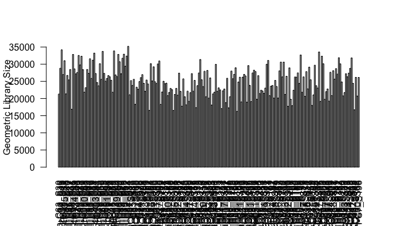

```r
Geo_Lib_Size <- colSums(log(counts+1))
barplot(Geo_Lib_Size, xlab="Cell", las=2, ylab = "Geometric Library Size")
```

```r
lcounts <- log(counts + 1)

# PC1 and Geometric library size correlation
pc1 = irlba(lcounts - rowMeans(lcounts), 1)$v[,1] ## partial SVD
cor(Geo_Lib_Size, pc1)
```

```
## [1] 0.9918327
```

## Run tSNE to cluster islet cells.

For comparison purposes, we applied tSNE on read counts of all genes. We used the Rtsne R package with default settings for this analyses. Genes are colored with respect to the expression of marker genes.

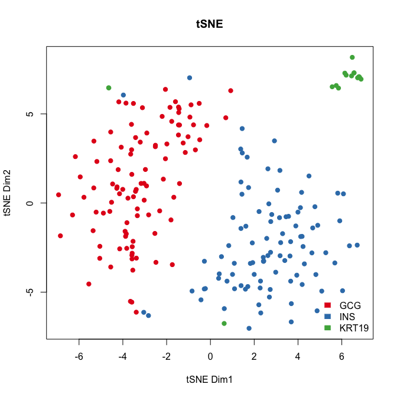

```r
set.seed(323542534)
tsne.res <- Rtsne(t(lcounts), dims = 2)

plot(tsne.res$Y, main="tSNE", xlab="tSNE Dim1", ylab="tSNE Dim2", pch=21, col=color.vec[Cell_Type], bg=color.vec[Cell_Type], oma=c(4,4,6,12))
legend("bottomright", levels(Cell_Type), border="white",fill=color.vec, bty="n")
```

## Run IA-SVA

Here, we first run IA-SVA using Patient_ID, Batch and Geo_Lib_Size as known factors and identify 5 hidden factors. Since cell type is not used as a known factor in this analyses, IA-SVA will detect the heterogeneity associated with the cell types.

```r
mod <- model.matrix(~Patient_ID+Batch+Geo_Lib_Size)
iasva.res<- iasva(t(counts), mod[,-1],verbose=FALSE, permute=FALSE, num.sv=5)
```

```
## IA-SVA running...
## SV1 Detected!
## SV2 Detected!
## SV3 Detected!
## SV4 Detected!
## SV5 Detected!
## # of significant surrogate variables: 5
```

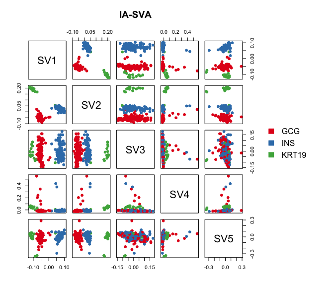

```r
iasva.sv <- iasva.res$sv

#with color-coding based on true cell-type
pairs(iasva.sv, main="IA-SVA", pch=21, col=color.vec[Cell_Type], bg=color.vec[Cell_Type], oma=c(4,4,6,14))
legend("right", levels(Cell_Type), border="white", fill=color.vec, bty="n")
```

```r
cor(Geo_Lib_Size, iasva.sv)
```

```
##            SV1        SV2        SV3       SV4       SV5
## [1,] 0.1283139 0.08603397 -0.6843428 0.1774588 0.6897538
```

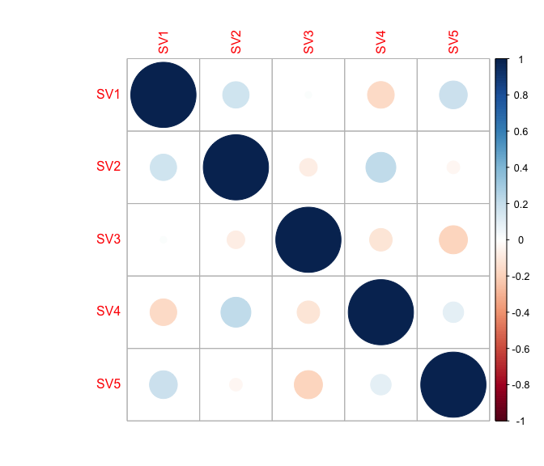

```r
corrplot(cor(iasva.sv))
```

As shown in the above figure, the fist two SVs (SV1 and SV2) separate cell types.

## Find marker genes for SV1 and SV2.

Here, using the find.markers() function we find marker genes significantly associated with SV1 and SV2 (multiple testing adjusted p-value < 0.05, default significance cutoff, a high R-squared value: R-squared > 0.4).

```r
marker.counts <- find.markers(t(counts), as.matrix(iasva.sv[,c(1,2)]), rsq.cutoff = 0.4)
```

```
## # of markers (SV1): 36
## # of markers (SV2): 55
## total # of unique markers:  86
```

```r
nrow(marker.counts)
```

```
## [1] 86
```

```r
anno.col <- data.frame(Cell_Type=Cell_Type)
rownames(anno.col) <- colnames(marker.counts)
head(anno.col)
```

```
##             Cell_Type
## 4th-C63_S30       GCG
## 4th-C66_S36       GCG
## 4th-C7_S15        INS
## 4th-C18_S31       GCG
## 4th-C5_S8         INS
## 4th-C57_S18       GCG
```

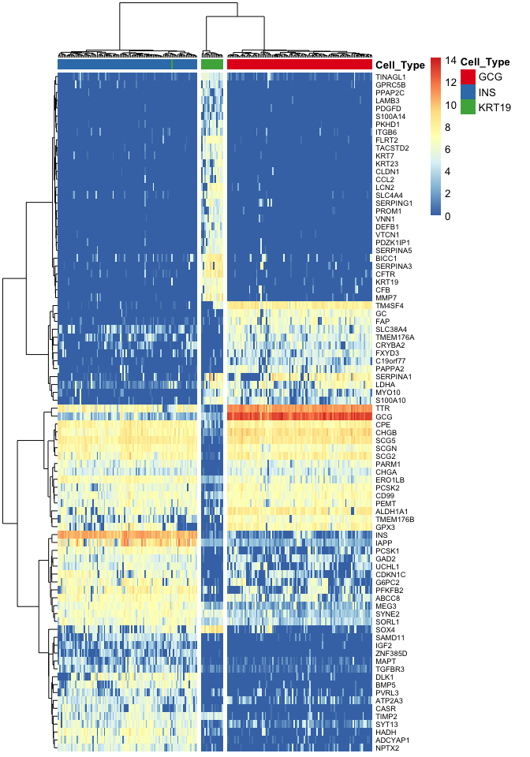

```r
cell.type.col <- color.vec[1:3]
names(cell.type.col) <- c("GCG","INS","KRT19")
anno.colors <- list(Cell_Type=cell.type.col)

pheatmap(log(marker.counts+1), show_colnames =FALSE, fontsize_row = 7, clustering_method = "ward.D2", cutree_cols = 3, annotation_col = anno.col, annotation_colors = anno.colors)
```

This list include 86 genes including INS, GCG, and KRT19. In the case of islet cells, marker genes are well established and IA-SVA did an excellent job of redefining these markers along with some other highly informative genes. Therefore, IA-SVA can be effectively used to uncover heterogeneity associated with cell types and can reveal genes that are expressed in a cell-specific manner.

## Run tSNE post IA-SVA, i.e., run tSNE on marker genes for SV1 and SV2 obtained from IA-SVA.

Here, we apply tSNE on the marker genes for SV1 and SV2

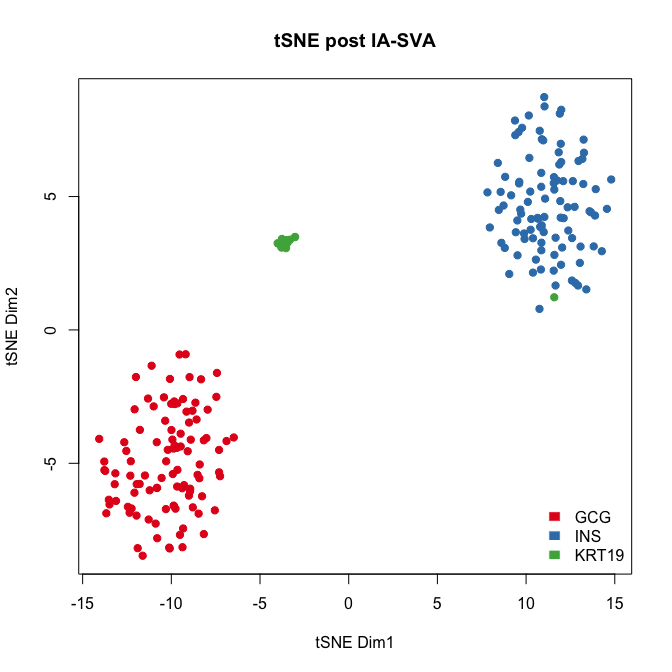

```r
set.seed(3445462)
tsne.res <- Rtsne(unique(t(log(marker.counts+1))), dims = 2)

plot(tsne.res$Y, main="tSNE post IA-SVA", xlab="tSNE Dim1", ylab="tSNE Dim2", pch=21, col=color.vec[Cell_Type], bg=color.vec[Cell_Type], oma=c(4,4,6,12))
legend("bottomright", levels(Cell_Type), border="white", fill=color.vec, bty="n")
```

tSNE conducted on genes selected via IA-SVA very clearly seperates cells into their corresponding clusters. Moreover, this analyses also revealed one cell (green cell clustered together with blue cells) that is potentially mislabeled in the original analyses.